# Quantium Task 1

```python
import numpy as np
import pandas as pd
import matplotlib.pyplot as plt
%matplotlib inline

import warnings
warnings.filterwarnings('ignore')
```

```python
transaction_data = pd.read_excel('C:/Users/Guoli/Documents/Data Science Material/Projects/Quantium/QVI_transaction_data.xlsx')
```

```python
transaction_data.head()
```

|  | DATE | STORE_NBR | LYLTY_CARD_NBR | TXN_ID | PROD_NBR | PROD_NAME | PROD_QTY | TOT_SALES |
| --- | --- | --- | --- | --- | --- | --- | --- | --- |
| 0 | 2018-10-17 | 1 | 1000 | 1 | 5 | Natural Chip Compny SeaSalt175g | 2 | 6.0 |
| 1 | 2019-05-14 | 1 | 1307 | 348 | 66 | CCs Nacho Cheese 175g | 3 | 6.3 |
| 2 | 2019-05-20 | 1 | 1343 | 383 | 61 | Smiths Crinkle Cut Chips Chicken 170g | 2 | 2.9 |
| 3 | 2018-08-17 | 2 | 2373 | 974 | 69 | Smiths Chip Thinly S/Cream&Onion 175g | 5 | 15.0 |
| 4 | 2018-08-18 | 2 | 2426 | 1038 | 108 | Kettle Tortilla ChpsHny&Jlpno Chili 150g | 3 | 13.8 |

# Notice the date format is not right

## Convert date into a right format in Excel: DATE-->General--->ShortDate---Save

```python
transaction_data.shape
```

```
(264836, 8)
```

```python
transaction_data['Prod_Weight'] = (
    transaction_data['PROD_NAME']
    .str.extract(r"(?i)(\d+(?:\.\d+)?)\s*[kmd]?g\b", expand=False)
    .astype(float)
)
```

[output not shown]

```python
transaction_data = transaction_data.drop(columns = ['Weight'])
transaction_data.head()
```

|  | DATE | STORE_NBR | LYLTY_CARD_NBR | TXN_ID | PROD_NBR | PROD_NAME | PROD_QTY | TOT_SALES | Prod_Weight |
| --- | --- | --- | --- | --- | --- | --- | --- | --- | --- |
| 0 | 2018-10-17 | 1 | 1000 | 1 | 5 | Natural Chip Compny SeaSalt175g | 2 | 6.0 | 175.0 |
| 1 | 2019-05-14 | 1 | 1307 | 348 | 66 | CCs Nacho Cheese 175g | 3 | 6.3 | 175.0 |
| 2 | 2019-05-20 | 1 | 1343 | 383 | 61 | Smiths Crinkle Cut Chips Chicken 170g | 2 | 2.9 | 170.0 |
| 3 | 2018-08-17 | 2 | 2373 | 974 | 69 | Smiths Chip Thinly S/Cream&Onion 175g | 5 | 15.0 | 175.0 |
| 4 | 2018-08-18 | 2 | 2426 | 1038 | 108 | Kettle Tortilla ChpsHny&Jlpno Chili 150g | 3 | 13.8 | 150.0 |

```python
#Remove special characters and product weights
spec_chars = ["!",'"',"#","%","&","'","(",")",
              "*","+",",","-",".","/",":",";","<",
              "=",">","?","@","[","\\","]","^","_",
              "`","{","|","}","~","–","\d\w*"]
for char in spec_chars:
    transaction_data['PROD_NAME'] = transaction_data['PROD_NAME'].str.replace(char, ' ')
```

```python
transaction_data.head()
```

|  | DATE | STORE_NBR | LYLTY_CARD_NBR | TXN_ID | PROD_NBR | PROD_NAME | PROD_QTY | TOT_SALES | Prod_Weight |
| --- | --- | --- | --- | --- | --- | --- | --- | --- | --- |
| 0 | 2018-10-17 | 1 | 1000 | 1 | 5 | Natural Chip Compny SeaSalt | 2 | 6.0 | 175.0 |
| 1 | 2019-05-14 | 1 | 1307 | 348 | 66 | CCs Nacho Cheese | 3 | 6.3 | 175.0 |
| 2 | 2019-05-20 | 1 | 1343 | 383 | 61 | Smiths Crinkle Cut Chips Chicken | 2 | 2.9 | 170.0 |
| 3 | 2018-08-17 | 2 | 2373 | 974 | 69 | Smiths Chip Thinly S Cream Onion | 5 | 15.0 | 175.0 |
| 4 | 2018-08-18 | 2 | 2426 | 1038 | 108 | Kettle Tortilla ChpsHny Jlpno Chili | 3 | 13.8 | 150.0 |

```python
long_string = ' '.join(transaction_data['PROD_NAME'])
init_list = long_string.split()
#print(init_list[:99])
```

[output not shown]

```python
#Count frequency
frequency = {}
for item in init_list:
    if item in frequency:
        frequency[item] = frequency[item] + 1
    else:
        frequency[item] = 1
sorted(frequency.items(), key=lambda x: x[1], reverse=True)
```

```
[('Chips', 49770),
 ('Kettle', 41288),
 ('Smiths', 28860),
 ('Salt', 27976),
 ('Cheese', 27890),
 ('Pringles', 25102),
 ('Doritos', 24962),
 ('Crinkle', 23960),
 ('Corn', 22063),
 ('Original', 21560),
 ('Cut', 20754),
 ('Chip', 18645),
 ('Chicken', 18577),
 ('Salsa', 18094),
 ('Cream', 16926),
 ('Chilli', 15390),
 ('Sea', 14145),
 ('Thins', 14075),
 ('Sour', 13882),
 ('Crisps', 12607),
 ('Vinegar', 12402),
 ('RRD', 11894),
 ('Sweet', 11060),
 ('Infuzions', 11057),
 ('Supreme', 10963),
 ('Chives', 10951),
 ('WW', 10320),
 ('Cobs', 9693),
 ('Popd', 9693),
 ('Tortilla', 9580),
 ('Tostitos', 9471),
 ('Twisties', 9454),
 ('BBQ', 9434),
 ('Sensations', 9429),
 ('Lime', 9347),
 ('Old', 9324),
 ('El', 9324),
 ('Paso', 9324),
 ('Dip', 9324),
 ('Swt', 7987),
```

[output cut: 143 more lines]

```
 ('Puffs', 1448),
 ('Originl', 1441),
 ('saltd', 1441),
 ('CutSalt', 1440),
 ('OnionDip', 1438),
 ('Chikn', 1434),
 ('Aioli', 1434),
 ('Sunbites', 1432),
 ('Whlegrn', 1432),
 ('Frch', 1432),
 ('Onin', 1432),
 ('Pc', 1431),
 ('NCC', 1419),
 ('Garden', 1419),
 ('Fries', 1418)]
```

```python
#Remove rows that contains Salsa products
transaction_data['PROD_NAME'] = transaction_data['PROD_NAME'].apply(lambda x: x.lower())
transaction_data = transaction_data[~transaction_data['PROD_NAME'].str.contains("salsa")]
transaction_data['PROD_NAME'] = transaction_data['PROD_NAME'].apply(lambda x: x.title())
transaction_data.shape
```

```
(246742, 9)
```

```python
#check if there is null value
transaction_data.isnull().sum().sum()
```

```
0
```

```python
#check outlier values
transaction_data['PROD_QTY'].value_counts()
```

```
2      220070
1       25476
5         415
3         408
4         371
200         2
Name: PROD_QTY, dtype: int64
```

```python
transaction_data.loc[transaction_data['PROD_QTY'] == 200, :]
```

|  | DATE | STORE_NBR | LYLTY_CARD_NBR | TXN_ID | PROD_NBR | PROD_NAME | PROD_QTY | TOT_SALES | Prod_Weight |
| --- | --- | --- | --- | --- | --- | --- | --- | --- | --- |
| 69762 | 2018-08-19 | 226 | 226000 | 226201 | 4 | Dorito Corn Chp Supreme | 200 | 650.0 | 380.0 |
| 69763 | 2019-05-20 | 226 | 226000 | 226210 | 4 | Dorito Corn Chp Supreme | 200 | 650.0 | 380.0 |

We can see these 2 transactions of 200 packets are made by same lylty card nbr, we can look for more of card number 226000

```python
transaction_data.loc[transaction_data['LYLTY_CARD_NBR'] == 226000,:]
```

|  | DATE | STORE_NBR | LYLTY_CARD_NBR | TXN_ID | PROD_NBR | PROD_NAME | PROD_QTY | TOT_SALES | Prod_Weight |
| --- | --- | --- | --- | --- | --- | --- | --- | --- | --- |
| 69762 | 2018-08-19 | 226 | 226000 | 226201 | 4 | Dorito Corn Chp Supreme | 200 | 650.0 | 380.0 |
| 69763 | 2019-05-20 | 226 | 226000 | 226210 | 4 | Dorito Corn Chp Supreme | 200 | 650.0 | 380.0 |

We can see that this card number only being used 2 time, so most likely it is an outlier of the dataset

```python
transaction_data = transaction_data[transaction_data['LYLTY_CARD_NBR'] != 226000]
```

```python
#check if it is deleted
transaction_data.loc[transaction_data['LYLTY_CARD_NBR'] == 226000]
```

|  | DATE | STORE_NBR | LYLTY_CARD_NBR | TXN_ID | PROD_NBR | PROD_NAME | PROD_QTY | TOT_SALES | Prod_Weight |
| --- | --- | --- | --- | --- | --- | --- | --- | --- | --- |

```python
#count the number of reansactions by dates
transaction_data['DATE'].nunique()#return number of unique elements in the object.
```

```
364
```

```python
pd.date_range(start = '2018-07-01', end = '2019-06-30').difference(transaction_data['DATE']) #check missing date
```

```
DatetimeIndex(['2018-12-25'], dtype='datetime64[ns]', freq=None)
```

```python
a = transaction_data.groupby('DATE')['TOT_SALES'].sum()

b = pd.DataFrame(a)
b
```

| DATE | TOT_SALES |
| --- | --- |
| 2018-07-01 | 4920.1 |
| 2018-07-02 | 4877.0 |
| 2018-07-03 | 4954.7 |
| 2018-07-04 | 4968.1 |
| 2018-07-05 | 4682.0 |
| ... | ... |
| 2019-06-26 | 4829.7 |
| 2019-06-27 | 4941.3 |
| 2019-06-28 | 4876.6 |
| 2019-06-29 | 5177.6 |
| 2019-06-30 | 5108.4 |

364 rows × 1 columns

```python
len(b)
```

```
364
```

```python
c = pd.DataFrame(index = pd.date_range(start = '2018-07-01', end = '2019-06-30'))
c['TOT_SALES'] = 0
d = c + b
d.fillna(0, inplace = True)
d.index.name = 'DATE'
d
```

| DATE | TOT_SALES |
| --- | --- |
| 2018-07-01 | 4920.1 |
| 2018-07-02 | 4877.0 |
| 2018-07-03 | 4954.7 |
| 2018-07-04 | 4968.1 |
| 2018-07-05 | 4682.0 |
| ... | ... |
| 2019-06-26 | 4829.7 |
| 2019-06-27 | 4941.3 |
| 2019-06-28 | 4876.6 |
| 2019-06-29 | 5177.6 |
| 2019-06-30 | 5108.4 |

365 rows × 1 columns

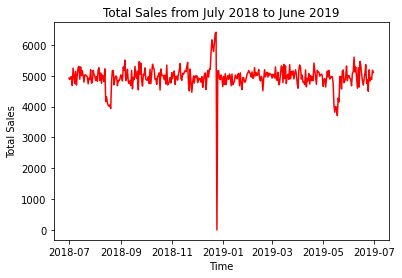

```python
x = d.index
y = d['TOT_SALES']
plt.plot(x, y, 'r-')
plt.title('Total Sales from July 2018 to June 2019')
plt.xlabel('Time')
plt.ylabel('Total Sales')
plt.show()
```

```python
d[d['TOT_SALES'] == 0]
```

| DATE | TOT_SALES |
| --- | --- |
| 2018-12-25 | 0.0 |

```python
#d_201807 = d['2018-07'].sum()
#d_201808  = d['2018-08'].sum()

import seaborn as sns
from datetime import datetime as dt
monthly_total_sales = d.groupby(pd.Grouper(freq = 'M')).sum()
monthly_total_sales[monthly_total_sales.TOT_SALES == monthly_total_sales.TOT_SALES.max()]
```

| DATE | TOT_SALES |
| --- | --- |
| 2018-12-31 | 156461.6 |

December gets to sale the most. let;s have a barplot view for each month.

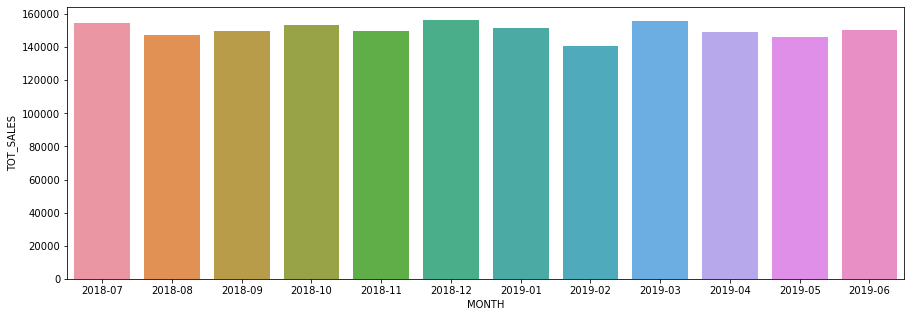

```python
months = ['2018-07', '2018-08', '2018-09', '2018-10',
               '2018-11', '2018-12', '2019-01', '2019-02',
               '2019-03', '2019-04', '2019-05', '2019-06']
monthly_total_sales['MONTH'] = months
plt.figure(figsize = (15,5))
sns.barplot(x = 'MONTH' , y = 'TOT_SALES' , data = monthly_total_sales)
```

Let's have a close look at december sales

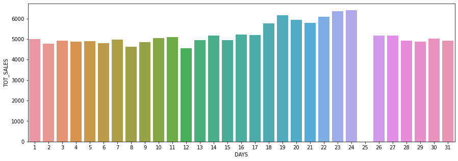

```python
d_december = d[(d.index < "2019-01-01") & (d.index > "2018-11-30")]
days = range(1,32)
d_december['DAYS'] = days
d_december
plt.figure(figsize = (15,5))
sns.barplot(x = 'DAYS' , y = 'TOT_SALES' , data = d_december)
```

We can see that the increase in sales occurs in the lead-up to Christmas and that there are zero sales on Christmas day itself. This is due to shops being closed on Christmas day.

```python
transaction_data.head()
```

|  | DATE | STORE_NBR | LYLTY_CARD_NBR | TXN_ID | PROD_NBR | PROD_NAME | PROD_QTY | TOT_SALES | Prod_Weight |
| --- | --- | --- | --- | --- | --- | --- | --- | --- | --- |
| 0 | 2018-10-17 | 1 | 1000 | 1 | 5 | Natural Chip Compny Seasalt | 2 | 6.0 | 175.0 |
| 1 | 2019-05-14 | 1 | 1307 | 348 | 66 | Ccs Nacho Cheese | 3 | 6.3 | 175.0 |
| 2 | 2019-05-20 | 1 | 1343 | 383 | 61 | Smiths Crinkle Cut Chips Chicken | 2 | 2.9 | 170.0 |
| 3 | 2018-08-17 | 2 | 2373 | 974 | 69 | Smiths Chip Thinly S Cream Onion | 5 | 15.0 | 175.0 |
| 4 | 2018-08-18 | 2 | 2426 | 1038 | 108 | Kettle Tortilla Chpshny Jlpno Chili | 3 | 13.8 | 150.0 |

```python
transaction_data['Prod_Weight'] = transaction_data['Prod_Weight'].astype(int)
```

[output not shown]

```python
transaction_data.head()
```

|  | DATE | STORE_NBR | LYLTY_CARD_NBR | TXN_ID | PROD_NBR | PROD_NAME | PROD_QTY | TOT_SALES | Prod_Weight |
| --- | --- | --- | --- | --- | --- | --- | --- | --- | --- |
| 0 | 2018-10-17 | 1 | 1000 | 1 | 5 | Natural Chip Compny Seasalt | 2 | 6.0 | 175 |
| 1 | 2019-05-14 | 1 | 1307 | 348 | 66 | Ccs Nacho Cheese | 3 | 6.3 | 175 |
| 2 | 2019-05-20 | 1 | 1343 | 383 | 61 | Smiths Crinkle Cut Chips Chicken | 2 | 2.9 | 170 |
| 3 | 2018-08-17 | 2 | 2373 | 974 | 69 | Smiths Chip Thinly S Cream Onion | 5 | 15.0 | 175 |
| 4 | 2018-08-18 | 2 | 2426 | 1038 | 108 | Kettle Tortilla Chpshny Jlpno Chili | 3 | 13.8 | 150 |

Let's check if the pack sizes look sensible

```python
transaction_data['Prod_Weight'].unique()
```

```
array([175, 170, 150, 330, 210, 270, 220, 125, 110, 134, 380, 180, 165,
       135, 250, 200, 160, 190,  90,  70])
```

```python
print(transaction_data.Prod_Weight.max())
print(transaction_data.Prod_Weight.min())
```

```
380
70
```

The largest size is 380g and the smallest size is 70g - seems sensible! Let's plot a histogram of Prod_Weight showing the number of transactions by pack size

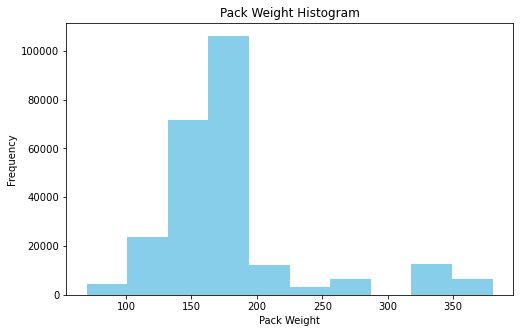

```python
plt.figure(figsize = (8, 5))
plt.hist(transaction_data['Prod_Weight'], color = 'skyblue')
plt.xlabel('Pack Weight')
plt.ylabel('Frequency')
plt.title('Pack Weight Histogram')
```

Pack sizes created look reasonable.

Now to create brands. Extract brand name from PROD_NAME and create new column called BRAND

```python
partition = transaction_data['PROD_NAME'].str.partition()
partition
```

|  | 0 | 1 | 2 |
| --- | --- | --- | --- |
| 0 | Natural |  | Chip Compny Seasalt |
| 1 | Ccs |  | Nacho Cheese |
| 2 | Smiths |  | Crinkle Cut Chips Chicken |
| 3 | Smiths |  | Chip Thinly S Cream Onion |
| 4 | Kettle |  | Tortilla Chpshny Jlpno Chili |
| ... | ... | ... | ... |
| 264831 | Kettle |  | Sweet Chilli And Sour Cream |
| 264832 | Tostitos |  | Splash Of Lime |
| 264833 | Doritos |  | Mexicana |
| 264834 | Doritos |  | Corn Chip Mexican Jalapeno |
| 264835 | Tostitos |  | Splash Of Lime |

246740 rows × 3 columns

```python
transaction_data['BRAND'] = partition[0]
```

```python
transaction_data.head()
```

|  | DATE | STORE_NBR | LYLTY_CARD_NBR | TXN_ID | PROD_NBR | PROD_NAME | PROD_QTY | TOT_SALES | Prod_Weight | BRAND |
| --- | --- | --- | --- | --- | --- | --- | --- | --- | --- | --- |
| 0 | 2018-10-17 | 1 | 1000 | 1 | 5 | Natural Chip Compny Seasalt | 2 | 6.0 | 175 | Natural |
| 1 | 2019-05-14 | 1 | 1307 | 348 | 66 | Ccs Nacho Cheese | 3 | 6.3 | 175 | Ccs |
| 2 | 2019-05-20 | 1 | 1343 | 383 | 61 | Smiths Crinkle Cut Chips Chicken | 2 | 2.9 | 170 | Smiths |
| 3 | 2018-08-17 | 2 | 2373 | 974 | 69 | Smiths Chip Thinly S Cream Onion | 5 | 15.0 | 175 | Smiths |
| 4 | 2018-08-18 | 2 | 2426 | 1038 | 108 | Kettle Tortilla Chpshny Jlpno Chili | 3 | 13.8 | 150 | Kettle |

```python
transaction_data['BRAND'].unique()
```

```
array(['Natural', 'Ccs', 'Smiths', 'Kettle', 'Grain', 'Doritos',
       'Twisties', 'Ww', 'Thins', 'Burger', 'Ncc', 'Cheezels', 'Infzns',
       'Red', 'Pringles', 'Dorito', 'Infuzions', 'Smith', 'Grnwves',
       'Tyrrells', 'Cobs', 'French', 'Rrd', 'Tostitos', 'Cheetos',
       'Woolworths', 'Snbts', 'Sunbites'], dtype=object)
```

Some of the brand names look like they are of the same brands - such as RED and RRD, which are both Red Rock Deli chips. Let's combine these together.

```python
transaction_data['BRAND'].replace('Smithss', 'Smiths', inplace = True)
transaction_data['BRAND'].replace(['Red', 'Rrd'], 'Red Rock Deli', inplace = True)
transaction_data['BRAND'].replace('Ncc', 'Natural', inplace = True)
transaction_data['BRAND'].replace('Dorito', 'Doritos', inplace = True)
transaction_data['BRAND'].replace('Infzns', 'Infuzions', inplace = True)
transaction_data['BRAND'].replace('Ww', 'Woolworths', inplace = True)
transaction_data['BRAND'].replace('Snbts', 'Sunbites', inplace = True)
transaction_data['BRAND'].unique()
```

[output not shown]

```python
transaction_data.groupby('BRAND').TOT_SALES.sum().sort_values(ascending = False)
```

```
BRAND
Kettle           390239.8
Doritos          226329.9
Smiths           217492.0
Pringles         177655.5
Infuzions         99047.6
Thins             88852.5
Red Rock Deli     87607.5
Twisties          81522.1
Tostitos          79789.6
Cobs              70569.8
Tyrrells          51647.4
Grain             43048.8
Natural           42318.0
Woolworths        41059.1
Cheezels          40029.9
Ccs               18078.9
Cheetos           16884.5
Sunbites           9676.4
Grnwves            8568.4
French             7929.0
Burger             6831.0
Name: TOT_SALES, dtype: float64
```

We can see that brand Kettle sales the most

#### Examining customer data

```python
customer_data = pd.read_csv('C:/Users/Guoli/Documents/Data Science Material/Projects/Quantium/QVI_purchase_behaviour.csv')
customer_data.head()
```

|  | LYLTY_CARD_NBR | LIFESTAGE | PREMIUM_CUSTOMER |
| --- | --- | --- | --- |
| 0 | 1000 | YOUNG SINGLES/COUPLES | Premium |
| 1 | 1002 | YOUNG SINGLES/COUPLES | Mainstream |
| 2 | 1003 | YOUNG FAMILIES | Budget |
| 3 | 1004 | OLDER SINGLES/COUPLES | Mainstream |
| 4 | 1005 | MIDAGE SINGLES/COUPLES | Mainstream |

```python
customer_data.describe()
```

|  | LYLTY_CARD_NBR |
| --- | --- |
| count | 7.263700e+04 |
| mean | 1.361859e+05 |
| std | 8.989293e+04 |
| min | 1.000000e+03 |
| 25% | 6.620200e+04 |
| 50% | 1.340400e+05 |
| 75% | 2.033750e+05 |
| max | 2.373711e+06 |

```python
customer_data['LIFESTAGE'].nunique()
```

```
7
```

```python
customer_data['LYLTY_CARD_NBR'].nunique()
```

```
72637
```

```python
customer_data.shape
```

```
(72637, 3)
```

We can see that each card number is unique.

```python
customer_data['LIFESTAGE'].value_counts().sort_values(ascending = False)
```

```
RETIREES                  14805
OLDER SINGLES/COUPLES     14609
YOUNG SINGLES/COUPLES     14441
OLDER FAMILIES             9780
YOUNG FAMILIES             9178
MIDAGE SINGLES/COUPLES     7275
NEW FAMILIES               2549
Name: LIFESTAGE, dtype: int64
```

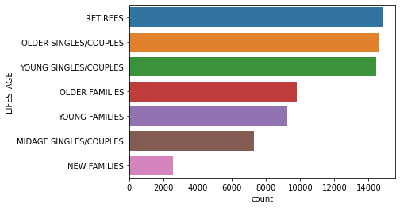

```python
sns.countplot(y = customer_data['LIFESTAGE'], order = customer_data['LIFESTAGE'].value_counts().index,  data = customer_data )
```

```python
#value counts for premium customers
customer_data['PREMIUM_CUSTOMER'].value_counts().sort_values(ascending = False)
```

```
Mainstream    29245
Budget        24470
Premium       18922
Name: PREMIUM_CUSTOMER, dtype: int64
```

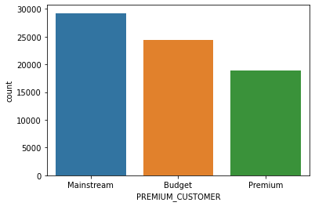

```python
sns.countplot(x = customer_data['PREMIUM_CUSTOMER'], order = customer_data['PREMIUM_CUSTOMER'].value_counts().index,  data = customer_data )
```

#### Merge transaction data to customer data

```python
merge_data = pd.merge(transaction_data, customer_data)
merge_data.shape
```

```
(246740, 12)
```

```python
merge_data.isnull().sum()
```

```
DATE                0
STORE_NBR           0
LYLTY_CARD_NBR      0
TXN_ID              0
PROD_NBR            0
PROD_NAME           0
PROD_QTY            0
TOT_SALES           0
Prod_Weight         0
BRAND               0
LIFESTAGE           0
PREMIUM_CUSTOMER    0
dtype: int64
```

Great, there are no nulls! So all our customers in the transaction data has been accounted for in the customer dataset.

## Data analysis on customer segments

Now that the data is ready for analysis, we can define some metrics of interest to the client:

- Who spends the most on chips (total sales), describing customers by lifestage and how premium their general purchasing behaviour is
- How many customers are in each segment
- How many chips are bought per customer by segment
- What's the average chip price by customer segment

Let's start with calculating total sales by LIFESTAGE and PREMIUM_CUSTOMER and plotting the split by these segments to describe which customer segment contribute most to chip sales.

```python
s = merge_data.groupby(['PREMIUM_CUSTOMER', 'LIFESTAGE']).TOT_SALES.sum()
s1 = pd.DataFrame(s)

s1 = s1.sort_values(by = 'TOT_SALES', ascending = False)
s1
```

| PREMIUM_CUSTOMER | LIFESTAGE | TOT_SALES |
| --- | --- | --- |
| Budget | OLDER FAMILIES | 156863.75 |
| Mainstream | YOUNG SINGLES/COUPLES | 147582.20 |
|  | RETIREES | 145168.95 |
| Budget | YOUNG FAMILIES | 129717.95 |
|  | OLDER SINGLES/COUPLES | 127833.60 |
| Mainstream | OLDER SINGLES/COUPLES | 124648.50 |
| Premium | OLDER SINGLES/COUPLES | 123537.55 |
| Budget | RETIREES | 105916.30 |
| Mainstream | OLDER FAMILIES | 96413.55 |
| Premium | RETIREES | 91296.65 |
| Mainstream | YOUNG FAMILIES | 86338.25 |
|  | MIDAGE SINGLES/COUPLES | 84734.25 |
| Premium | YOUNG FAMILIES | 78571.70 |
|  | OLDER FAMILIES | 75242.60 |
| Budget | YOUNG SINGLES/COUPLES | 57122.10 |
| Premium | MIDAGE SINGLES/COUPLES | 54443.85 |
|  | YOUNG SINGLES/COUPLES | 39052.30 |
| Budget | MIDAGE SINGLES/COUPLES | 33345.70 |
|  | NEW FAMILIES | 20607.45 |
| Mainstream | NEW FAMILIES | 15979.70 |
| Premium | NEW FAMILIES | 10760.80 |

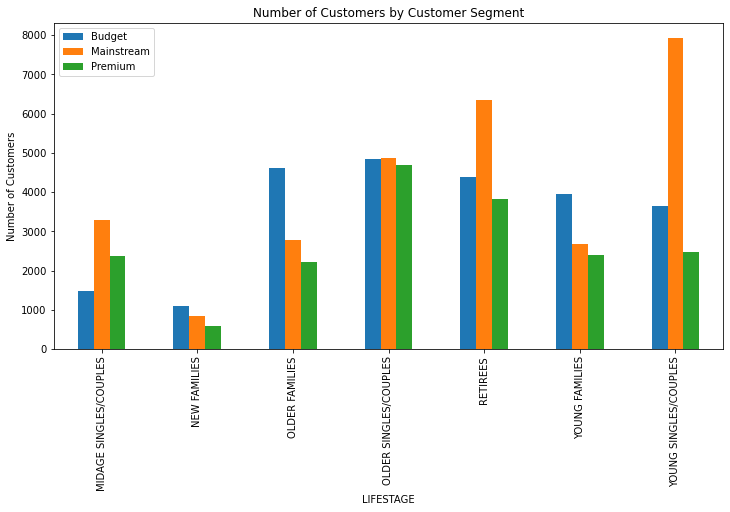

```python
s2 = pd.DataFrame(merge_data.groupby(['LIFESTAGE', 'PREMIUM_CUSTOMER']).LYLTY_CARD_NBR.nunique())
s2.unstack().plot(kind = 'bar',  figsize = (12, 6), title = 'Number of Customers by Customer Segment')
plt.ylabel('Number of Customers')
plt.legend(['Budget', 'Mainstream', 'Premium'], loc = 2)
```

There are more Mainstream - young singles/couples and Mainstream - retirees who buy chips. This contributes to there being more sales to these customer segments but this is not a major driver for the Budget - Older families segment.

Higher sales may also be driven by more units of chips being bought per customer. Let's have a look at this next.

#### Average number of units per customer by LIFESTAGE and PREMIUM_CUSTOMER

```python
top = merge_data.groupby(['PREMIUM_CUSTOMER', 'LIFESTAGE']).PROD_QTY.sum()
botm = merge_data.groupby(['PREMIUM_CUSTOMER', 'LIFESTAGE']).LYLTY_CARD_NBR.nunique()
avg_units = top/botm
avg_units = pd.DataFrame(avg_units, columns = {'Average Unit per Customer'})
#avg_units.sort_values(by = 'Average Unit per Customer', ascending = False)
avg_units
```

| PREMIUM_CUSTOMER | LIFESTAGE | Average Unit per Customer |
| --- | --- | --- |
| Budget | MIDAGE SINGLES/COUPLES | 6.026459 |
|  | NEW FAMILIES | 4.821527 |
|  | OLDER FAMILIES | 9.076773 |
|  | OLDER SINGLES/COUPLES | 6.781398 |
|  | RETIREES | 6.141847 |
|  | YOUNG FAMILIES | 8.722995 |
|  | YOUNG SINGLES/COUPLES | 4.250069 |
| Mainstream | MIDAGE SINGLES/COUPLES | 6.432080 |
|  | NEW FAMILIES | 4.891566 |
|  | OLDER FAMILIES | 9.255380 |
|  | OLDER SINGLES/COUPLES | 6.712021 |
|  | RETIREES | 5.925920 |
|  | YOUNG FAMILIES | 8.638361 |
|  | YOUNG SINGLES/COUPLES | 4.575597 |
| Premium | MIDAGE SINGLES/COUPLES | 6.078514 |
|  | NEW FAMILIES | 4.815652 |
|  | OLDER FAMILIES | 9.071717 |
|  | OLDER SINGLES/COUPLES | 6.769543 |
|  | RETIREES | 6.103358 |
|  | YOUNG FAMILIES | 8.716013 |
|  | YOUNG SINGLES/COUPLES | 4.264113 |

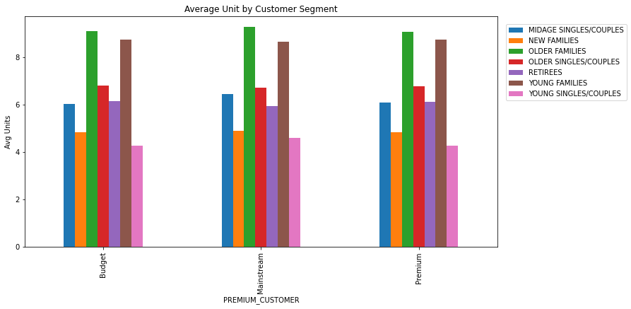

```python
avg_units.unstack().plot(kind = 'bar', figsize = (12, 6), title = 'Average Unit by Customer Segment')
plt.ylabel('Avg Units')
#plt.legend(['Budget', 'Mainstream', 'Premium'], loc = 2)
plt.legend(['MIDAGE SINGLES/COUPLES','NEW FAMILIES','OLDER FAMILIES','OLDER SINGLES/COUPLES','RETIREES','YOUNG FAMILIES','YOUNG SINGLES/COUPLES'], loc = 'center right', bbox_to_anchor=(1.28, 0.8))
```

Older families and young families in general buy more chips per customer

#### Average price per unit by LIFESTAGE and PREMIUM_CUSTOMER

```python
avg_price = merge_data.groupby(['PREMIUM_CUSTOMER', 'LIFESTAGE']).TOT_SALES.sum() / merge_data.groupby(['PREMIUM_CUSTOMER', 'LIFESTAGE']).PROD_QTY.sum()
avg_price = avg_price = pd.DataFrame(avg_price, columns = {'Price per Unit'})
avg_price.head()
```

| PREMIUM_CUSTOMER | LIFESTAGE | Price per Unit |
| --- | --- | --- |
| Budget | MIDAGE SINGLES/COUPLES | 3.753878 |
|  | NEW FAMILIES | 3.931969 |
|  | OLDER FAMILIES | 3.747969 |
|  | OLDER SINGLES/COUPLES | 3.887529 |
|  | RETIREES | 3.932731 |

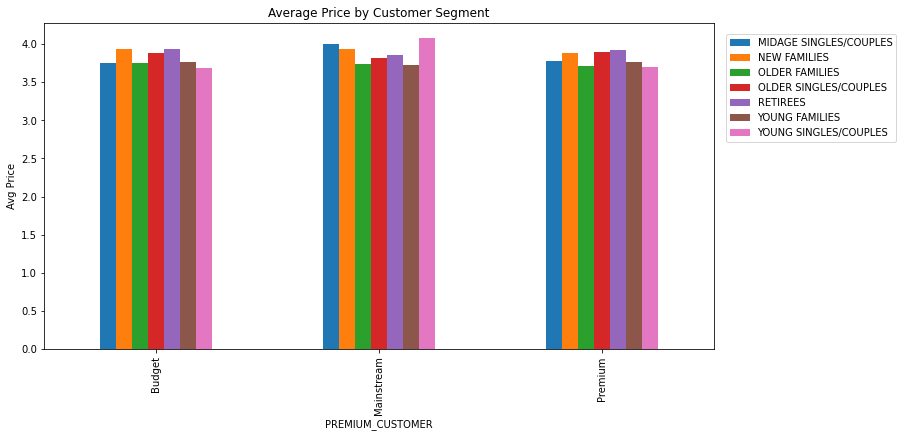

```python
avg_price.unstack().plot(kind = 'bar', figsize = (12, 6), title = 'Average Price by Customer Segment')
plt.ylabel('Avg Price')
plt.legend(['MIDAGE SINGLES/COUPLES','NEW FAMILIES','OLDER FAMILIES','OLDER SINGLES/COUPLES','RETIREES','YOUNG FAMILIES','YOUNG SINGLES/COUPLES'], loc = 'center right', bbox_to_anchor=(1.28, 0.8))
```

Mainstream midage and young singles and couples are more willing to pay more per packet of chips compared to their budget and premium counterparts. This may be due to premium shoppers being more likely to buy healthy snacks and when they buy chips, this is mainly for entertainment purposes rather than their own consumption. This is also supported by there being fewer premium midage and young singles and couples buying chips compared to their mainstream counterparts.

As the difference in average price per unit isn't large, we can check if this difference is statistically different.

```python
# Perform an independent t-test between mainstream vs non-mainstream midage(premium and budget midage) and young singles/couples to test this difference

# Create a new dataframe pricePerUnit
new_data = merge_data

# Create a new column under pricePerUnit called Price_Unit
new_data['Price_Unit'] = new_data['TOT_SALES'] / new_data['PROD_QTY']
new_data.head()
```

|  | DATE | STORE_NBR | LYLTY_CARD_NBR | TXN_ID | PROD_NBR | PROD_NAME | PROD_QTY | TOT_SALES | Prod_Weight | BRAND | LIFESTAGE | PREMIUM_CUSTOMER | Price_Unit |
| --- | --- | --- | --- | --- | --- | --- | --- | --- | --- | --- | --- | --- | --- |
| 0 | 2018-10-17 | 1 | 1000 | 1 | 5 | Natural Chip Compny Seasalt | 2 | 6.0 | 175 | Natural | YOUNG SINGLES/COUPLES | Premium | 3.00 |
| 1 | 2019-05-14 | 1 | 1307 | 348 | 66 | Ccs Nacho Cheese | 3 | 6.3 | 175 | Ccs | MIDAGE SINGLES/COUPLES | Budget | 2.10 |
| 2 | 2018-11-10 | 1 | 1307 | 346 | 96 | Ww Original Stacked Chips | 2 | 3.8 | 160 | Woolworths | MIDAGE SINGLES/COUPLES | Budget | 1.90 |
| 3 | 2019-03-09 | 1 | 1307 | 347 | 54 | Ccs Original | 1 | 2.1 | 175 | Ccs | MIDAGE SINGLES/COUPLES | Budget | 2.10 |
| 4 | 2019-05-20 | 1 | 1343 | 383 | 61 | Smiths Crinkle Cut Chips Chicken | 2 | 2.9 | 170 | Smiths | MIDAGE SINGLES/COUPLES | Budget | 1.45 |

```python
mainstream = new_data.loc[(new_data['PREMIUM_CUSTOMER'] == 'Mainstream') & ((new_data['LIFESTAGE'] == 'YOUNG SINGLES/COUPLES') | (new_data['LIFESTAGE'] == 'MIDAGE SINGLES/COUPLES') ), 'Price_Unit']
nonmainstream = new_data.loc[(new_data['PREMIUM_CUSTOMER'] != 'Mainstream') & ((new_data['LIFESTAGE'] == 'YOUNG SINGLES/COUPLES') | (new_data['LIFESTAGE'] == 'MIDAGE SINGLES/COUPLES') ), 'Price_Unit']
```

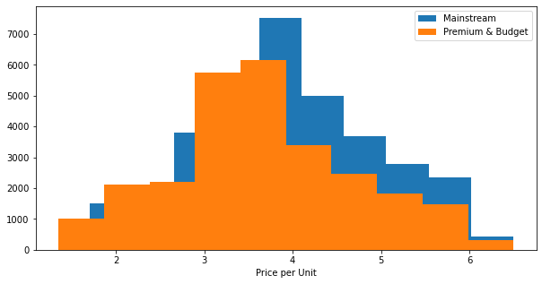

```python
plt.figure(figsize = (10, 5))
plt.hist(mainstream, label = 'Mainstream')
plt.hist(nonmainstream, label = 'Premium & Budget')
plt.legend()
plt.xlabel('Price per Unit')
```

```python
# Perform t-test

from scipy.stats import ttest_ind

ttest_ind(mainstream, nonmainstream)
```

```
Ttest_indResult(statistic=37.83196107667825, pvalue=2.235645611540966e-309)
```

Mainstream customers have higher average price per unit than that of non-mainstream customers.

## Deep dive into specific customer segments for insights

We have found quite a few interesting insights that we can dive deeper into. We might want to target customer segments that contribute the most to sales to retain them or further increase sales.

Let's look at Mainstream - young singles/couples. For instance, let's find out if they tend to buy a particular brand of chips.

```python
target = merge_data.loc[(merge_data['PREMIUM_CUSTOMER'] == 'Mainstream') & (merge_data['LIFESTAGE'] == 'YOUNG SINGLES/COUPLES'),:]
nontarget = merge_data.loc[(merge_data['PREMIUM_CUSTOMER'] != 'Mainstream') & (merge_data['LIFESTAGE'] != 'YOUNG SINGLES/COUPLES'),:]
target.head()
```

|  | DATE | STORE_NBR | LYLTY_CARD_NBR | TXN_ID | PROD_NBR | PROD_NAME | PROD_QTY | TOT_SALES | Prod_Weight | BRAND | LIFESTAGE | PREMIUM_CUSTOMER | Price_Unit |
| --- | --- | --- | --- | --- | --- | --- | --- | --- | --- | --- | --- | --- | --- |
| 221345 | 2018-08-16 | 1 | 1020 | 26 | 19 | Smiths Crinkle Cut Snag Sauce | 1 | 2.6 | 150 | Smiths | YOUNG SINGLES/COUPLES | Mainstream | 2.6 |
| 221346 | 2018-10-02 | 1 | 1020 | 27 | 7 | Smiths Crinkle Original | 1 | 5.7 | 330 | Smiths | YOUNG SINGLES/COUPLES | Mainstream | 5.7 |
| 221347 | 2019-05-02 | 1 | 1020 | 28 | 84 | Grnwves Plus Btroot Chilli Jam | 1 | 3.1 | 180 | Grnwves | YOUNG SINGLES/COUPLES | Mainstream | 3.1 |
| 221348 | 2018-08-17 | 1 | 1163 | 188 | 46 | Kettle Original | 1 | 5.4 | 175 | Kettle | YOUNG SINGLES/COUPLES | Mainstream | 5.4 |
| 221349 | 2019-02-07 | 1 | 1163 | 189 | 12 | Natural Chip Co Tmato Hrb Spce | 1 | 3.0 | 175 | Natural | YOUNG SINGLES/COUPLES | Mainstream | 3.0 |

Affinity to brand

```python
target_brand = target.loc[:, ['BRAND', 'PROD_QTY']]
target_sum = target_brand['PROD_QTY'].sum()
target_brand['Brand_Affinity'] = target['PROD_QTY']/target_sum
target_brand = pd.DataFrame(target_brand.groupby('BRAND')['Brand_Affinity'].sum())
target_brand

nontarget_brand = nontarget.loc[:, ['BRAND', 'PROD_QTY']]
nontarget_sum = nontarget_brand['PROD_QTY'].sum()
nontarget_brand['Non Brand_Affinity'] = nontarget['PROD_QTY']/nontarget_sum
nontarget_brand = pd.DataFrame(nontarget_brand.groupby('BRAND')['Non Brand_Affinity'].sum())
nontarget_brand.head()
```

| BRAND | Non Brand_Affinity |
| --- | --- |
| Burger | 0.006538 |
| Ccs | 0.018445 |
| Cheetos | 0.011759 |
| Cheezels | 0.018904 |
| Cobs | 0.038449 |

```python
# Merge the two dataframes together

brand_data = pd.merge(target_brand, nontarget_brand, left_index = True, right_index = True)
brand_data.head()
```

| BRAND | Brand_Affinity | Non Brand_Affinity |
| --- | --- | --- |
| Burger | 0.002926 | 0.006538 |
| Ccs | 0.011180 | 0.018445 |
| Cheetos | 0.008033 | 0.011759 |
| Cheezels | 0.017971 | 0.018904 |
| Cobs | 0.044638 | 0.038449 |

```python
brand_data['Affinity to Brand'] = brand_data['Brand_Affinity'] / brand_data['Non Brand_Affinity']
brand_data.sort_values(by = 'Affinity to Brand', ascending = False).head()
```

| BRAND | Brand_Affinity | Non Brand_Affinity | Affinity to Brand |
| --- | --- | --- | --- |
| Tyrrells | 0.031553 | 0.025715 | 1.227025 |
| Twisties | 0.046184 | 0.037933 | 1.217506 |
| Doritos | 0.122761 | 0.101171 | 1.213397 |
| Kettle | 0.197985 | 0.166560 | 1.188667 |
| Tostitos | 0.045411 | 0.038350 | 1.184100 |

We can see that: Mainstream young singles/couples are more likely to purchase Tyrrells, Twisties, and Doritos chips compared to other brands.

Let's also find out if our target segment tends to buy larger packs of chips.

#### Preferred pack size compared to the rest of the population

```python
target_weight = target.loc[:, ['Prod_Weight', 'PROD_QTY']]
target_weightsum = target_weight['PROD_QTY'].sum()
target_weight['Weight_Affinity'] = target['PROD_QTY']/target_weightsum
target_weight = pd.DataFrame(target_weight.groupby('Prod_Weight')['Weight_Affinity'].sum())
target_weight.head()

nontarget_weight = nontarget.loc[:, ['Prod_Weight', 'PROD_QTY']]
nontarget_weightsum = nontarget_weight['PROD_QTY'].sum()
nontarget_weight['Non Weight_Affinity'] = nontarget['PROD_QTY']/nontarget_weightsum
nontarget_weight = pd.DataFrame(nontarget_weight.groupby('Prod_Weight')['Non Weight_Affinity'].sum())
nontarget_weight.head()
```

| Prod_Weight | Non Weight_Affinity |
| --- | --- |
| 70 | 0.006284 |
| 90 | 0.012613 |
| 110 | 0.089575 |
| 125 | 0.005976 |
| 134 | 0.101110 |

```python
weight_data = pd.merge(target_weight, nontarget_weight, left_index = True, right_index = True)
weight_data.head()
```

| Prod_Weight | Weight_Affinity | Non Weight_Affinity |
| --- | --- | --- |
| 70 | 0.003037 | 0.006284 |
| 90 | 0.006349 | 0.012613 |
| 110 | 0.106280 | 0.089575 |
| 125 | 0.003009 | 0.005976 |
| 134 | 0.119420 | 0.101110 |

```python
weight_data['Affinity to Weight'] = weight_data['Weight_Affinity']/weight_data['Non Weight_Affinity']
weight_data.sort_values(by = 'Affinity to Weight', ascending = False).head()
```

| Prod_Weight | Weight_Affinity | Non Weight_Affinity | Affinity to Weight |
| --- | --- | --- | --- |
| 270 | 0.031829 | 0.025070 | 1.269608 |
| 380 | 0.032160 | 0.025711 | 1.250827 |
| 330 | 0.061284 | 0.050974 | 1.202243 |
| 110 | 0.106280 | 0.089575 | 1.186492 |
| 134 | 0.119420 | 0.101110 | 1.181090 |

We can see that mainstream singles/couples are more likely to purchase a 270g and 380g pack sizes compared to other pack sizes.

```python
merge_data.loc[merge_data['Prod_Weight'] == 270, 'BRAND'].unique()
```

```
array(['Twisties'], dtype=object)
```

```python
merge_data.loc[merge_data['Prod_Weight'] == 380, 'BRAND'].unique()
```

```
array(['Doritos', 'Smiths'], dtype=object)
```

## Conclusion:

3) Mainstream-young singles and couples are more willing to pay more per packet of chips compared to their budget and premium counterparts.

4) Mainstream-young singles/couples are more likely to purchase Tyrrells, Twisties, and Doritos chips compared to other brands.

5) Mainstream-singles/couples are more likely to purchase a 270g and 380g pack sizes compared to other pack sizes.

6) Mainstream-young/couples are more likely to purchase Twisties-270g and Doritos-380g chips.